# Tutorial1 :RNA seq data normalisation by TMM normalisation

Tanakamol Mahawan

2023-12-09

# Introduction

RNA-seq normalisation is crucial for adjusting raw data to account for factors that can affect the accuracy of analysis. These factors include sequencing depth, transcript length, and variability between samples or batches. Normalisation methods help to ensure that gene expression values are comparable across different samples or conditions, improving the reliability of downstream analyses. However, the best normalisation method can vary depending on the data and research question. It’s a vital step in RNA-seq data analysis.

# 1.Load Packages

loads necessary R packages for the tutorial requires functions from these packages for data manipulation, statistical analysis, and visualization. You may need to install some of them if they are not installed.

```r
library(edgeR)
library(tmaptools)
library(tidyverse)
library(reshape2)
```

```r
source("custom_functions.r") # source the built custom functions
```

# 2. Input the Data

Reads raw count data and phenotype information from CSV files. Make sure that the input data is raw count as EdgeR works on raw data.

This tutorial will show you only GSE79668 data as an example, you can follow the same steps to run with other data : TCGA-PAAD, PACA-AU and PACA-CA,and CPTAC-PDAC.

Please ensure that you use the raw RNA seq counts (not processed data e.g., RSEM , log2 normalised counts).

```r
# Read raw data and phenotype information
data_raw <- read.csv("GSE79668_count.csv", stringsAsFactors = FALSE)
data_raw <- data_raw[,-2]
pheno <- read.csv("pheno_GSE79668.csv", stringsAsFactors = FALSE)
head(pheno)
```

```
##       Sample_ID          CLASS  T  M  N stage_relative    sex AGE AGE_RANGE
## 1 T_10_11_A059a non_metastasis T1 M0 N0             IA   male  64   seniour
## 2 T_06_11_A455b non_metastasis T1 M0 N0             IA   male  79   seniour
## 3 T_07_02_A073a non_metastasis T2 M0 N0             IB female  28     young
## 4 T_10_11_A128a non_metastasis T2 M0 N0             IB   male  60   seniour
## 5 T_11_04_A026b non_metastasis T2 M0 N0             IB female  64   seniour
## 6 T_07_03_A187a non_metastasis T2 M0 N0             IB   male  68   seniour
##   diabetes.status  race Source.Name ENA_SAMPLE disease survival.status
## 1             yes White  GSM2100859 SRS1366086    PDAC            dead
## 2              no White  GSM2100865 SRS1366080    PDAC            dead
## 3             yes White  GSM2100877 SRS1366068    PDAC           alive
## 4             yes White  GSM2100893 SRS1366104    PDAC           alive
## 5             yes White  GSM2100898 SRS1366099    PDAC           alive
## 6              no White  GSM2100880 SRS1366064    PDAC            dead
##   survival.time
## 1          1564
## 2          2906
## 3          2995
## 4          1454
## 5          1505
## 6           432
```

# 3.Quality control

We will Conduct basic quality control by inspecting dimensions and structure of the raw data by subseting data to include only selected patients and removes any missing values. Quality control ensures that the initial dataset is suitable for analysis and removes any problematic entries.

```r
# Display dimensions and structure of raw data
dim(data_raw)
```

```
## [1] 47676    52
```

```r
head(data_raw)
```

```
##           gene_id T_03_11_A244a T_04_02_A274c T_04_04_A207b T_04_06_A027c
## 1 ENSG00000237851            25            12            44            67
## 2 ENSG00000174177           971          2095           567          1401
## 3 ENSG00000225538             0             0             0             0
## 4 ENSG00000257527            12             9             5             6
## 5 ENSG00000243765             2             1             0             0
## 6 ENSG00000151503          1461          3437           723          1186
##   T_04_12_A158b T_05_01_A082b T_05_03_A215c T_05_06_A121b T_05_08_A230b
## 1            34            29            17            10            23
## 2          1112          3397          2341          1960          1569
## 3             0             0             0             2             2
## 4            16            12            22            10            12
## 5             0             1             0             0             1
## 6          1042          2373          2205          3095          2125
##   T_06_01_A033a T_06_02_A026a T_06_04_A296a T_06_05_A309a T_06_06_A349a
```

[output cut: 62 more lines]

```r
# Subset data for selected patients and remove NAs
data_clean <- data_raw[, colnames(data_raw) %in% pheno$Sample_ID, ]
data_clean <- na.omit(data_clean)
dim(data_clean)
```

```
## [1] 47676    51
```

# 4.Create DGEList Object

Next, we create a DGEList object, a specific object used in edgeR for differential gene expression analysis. Then,display the first few counts.

We add library sizes that can be used for Normalisation and to account for variability in library sizes.

The DGEList object is a crucial step for downstream analysis, providing a framework for further statistical testing.

```r
# Create DGEList object
dgList <- DGEList(data_clean)

# View the first few counts
head(dgList[["counts"]])
```

```
##   T_03_11_A244a T_04_02_A274c T_04_04_A207b T_04_06_A027c T_04_12_A158b
## 1            25            12            44            67            34
## 2           971          2095           567          1401          1112
## 3             0             0             0             0             0
## 4            12             9             5             6            16
## 5             2             1             0             0             0
## 6          1461          3437           723          1186          1042
##   T_05_01_A082b T_05_03_A215c T_05_06_A121b T_05_08_A230b T_06_01_A033a
## 1            29            17            10            23            76
## 2          3397          2341          1960          1569           558
## 3             0             0             2             2             0
## 4            12            22            10            12            11
## 5             1             0             0             1             1
## 6          2373          2205          3095          2125           910
##   T_06_02_A026a T_06_04_A296a T_06_05_A309a T_06_06_A349a T_06_09_A196a
```

[output cut: 62 more lines]

```r
# Assign sample groups
samp_groups <- as.factor(pheno$CLASS)
dgList[["samples"]]$group <- samp_groups

# Add additional information to samples table
dgList[["samples"]]$lib.size
```

```
##  [1]  72070722  94077831  62383233  74756131  69184047  81390690  78583848
##  [8]  84954822  66849310  57495369  78288269  63011346  70897375  88735940
## [15]  58344737  56161576  36047617  24883565  58695551  74438502  60915759
## [22]  64143875  92770384  77561026  31634392  48522070  61993305  80131122
## [29]  92692244  57026734 108471768  71122141  89940922 101722247  80202226
## [36]  64114495  80932121  88445185  79184162  49929551  71744129  65217480
## [43]  79933351  84795155  90106485  86122717  96948895  81125575  83654229
## [50]  82976905  68713417
```

# 5.Filtering lowly expressed genes

Next,we filter genes based on expression levels and log-transforms counts per million using function filterByExpr. Filtering reduces noise and focuses the analysis on genes with sufficient expression levels.

```r
# Filter genes
keep <- filterByExpr(y = dgList, design = samp_groups)
dgList <- dgList[keep, ]

# Log-transform counts per million (CPM)
log_cpm <- cpm(dgList, log = TRUE)
```

# 6. Exploratory Data Analysis

Visualisation helps assess the data’s distribution and identify potential outliers or patterns.We generate a box plot and PCA plot for visualizing the data before normalisation.

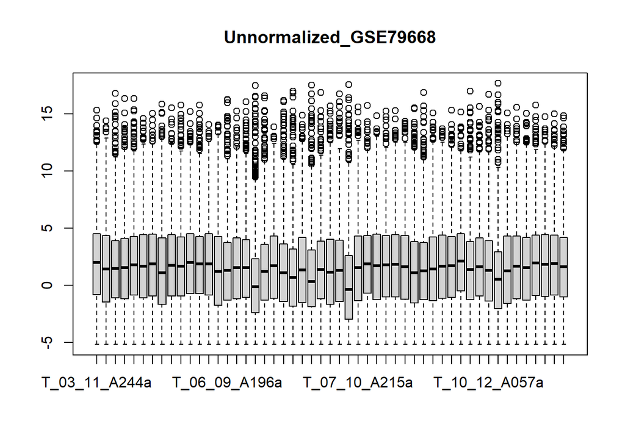

```r
# Box plot of unnormalized data
boxplot(log_cpm, main = "Unnormalized_GSE79668")
```

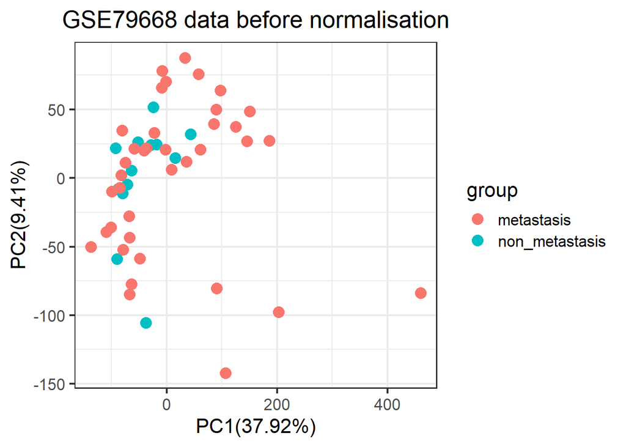

```r
# PCA plot
data01 <- t(as.matrix(dgList)) + 1
data01 <- log2(data01)
PCA_plot(data = data01, group = pheno$CLASS, title = "GSE79668 data before normalisation")
```

7. Normalisation using TMM

Normalisation using the TMM (trimmed mean of M-values) method is done using the calcNormFactors function from the edgeR package. MM Normalisation involves finding a scaling factor based on the trimmed mean of M-values, which helps account for differences in library size between samples.

The Normalisation step using the TMM method is crucial in preparing the data for downstream analyses, such as differential gene expression analysis. It improves the reliability of results and facilitates meaningful comparisons between different samples.

More information : Robinson, M.D., Oshlack, A. A scaling normalization method for differential expression analysis of RNA-seq data. Genome Biol 11, R25 (2010). https://doi.org/10.1186/gb-2010-11-3-r25

```r
# Normalize data using TMM
dgList <- calcNormFactors(dgList, method = "TMM")

# Display normalization factors
dgList$samples$norm.factors
```

```
##  [1] 1.2938088 1.0614781 0.9333192 1.0277311 1.1657954 1.1914912 1.3112179
##  [8] 1.0184716 1.3286992 1.1376064 1.3480366 1.2228439 1.3598160 1.0623954
## [15] 0.8434691 1.0764863 0.9966098 0.3429804 0.8050584 1.1888663 0.8151454
## [22] 0.5977149 0.9765990 0.5731539 0.9757983 1.0117973 0.8780469 0.3837543
## [29] 1.0970958 1.2925639 1.2037039 1.1795833 1.2127139 1.1148029 0.8577313
## [36] 0.9053954 1.0545802 1.1976132 1.1466432 1.4138930 0.8731486 1.1365707
## [43] 0.8869087 0.4708276 1.0773983 1.1066061 0.9878635 1.2033485 1.2203587
## [50] 1.2198893 1.1145965
```

```r
# Log-transform normalized counts
normalised_counts_log <- cpm(dgList, log = TRUE, normalised.lib.sizes = TRUE)
```

8. Data visualisation

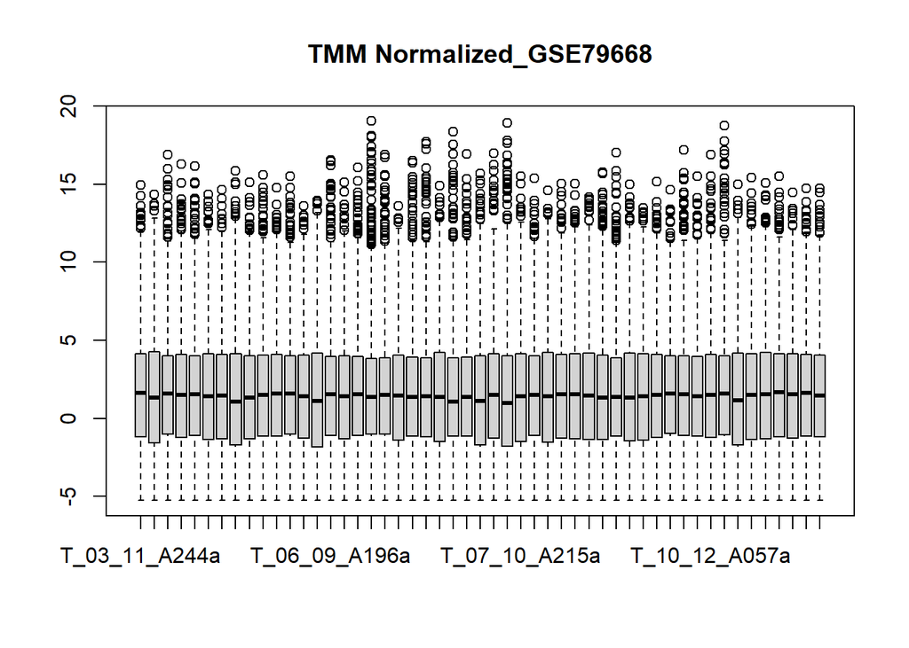

```r
# Box plot of normalized data
boxplot(normalised_counts_log, main = "TMM Normalized_GSE79668")
```

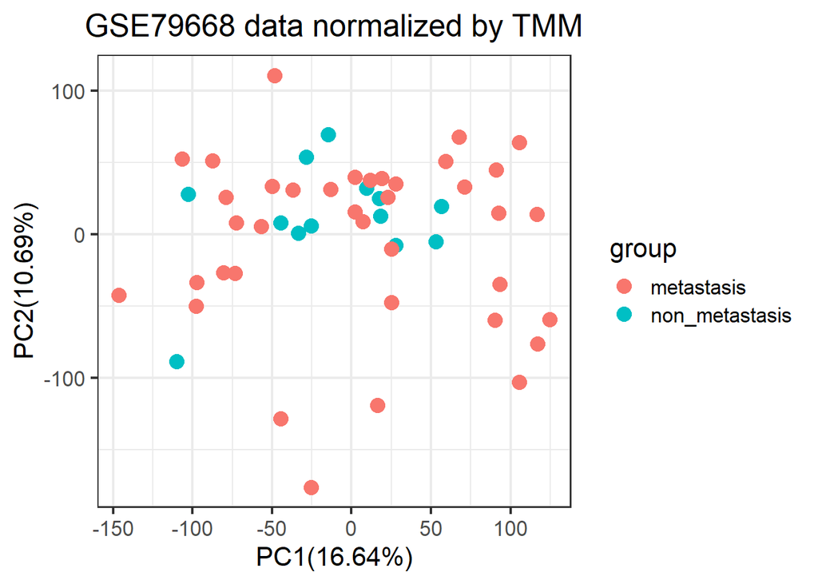

```r
# PCA plot of normalized data
data02 <- as.matrix(t(normalised_counts_log))
PCA_plot(data = data02, group = pheno$CLASS, title = "GSE79668 data normalized by TMM")
```

9.Save Results

```r
# Save normalized data
write.csv(normalised_counts_log, "normalised_log_GSE79668.csv")

# Save workspace
save.image("1_TMM_norm.rdata")
```